# What is data?

**Learning outcomes**

Identify different data types.

Here are 12 rows of a fictional dataset on a viral disease outbreak. The full dataset has 344 observations (rows), and 12 variables (columns). It describes imaginary participants from 3 fictional towns who fell ill with 3 strains of an unknown viral disease. Some measurements were taken from their blood.

| study_id | year | town | strain | age | sex | height | weight | immune_prot_A | immune_prot_B | immune_prot_C | immune_prot_D |
| --- | --- | --- | --- | --- | --- | --- | --- | --- | --- | --- | --- |
| ID262 | 2021 | Brenbo | G879 | 65 | male | 191.7948 | 110.20692 | 64.25698 | 354.7057 | 47.72071 | 2.974343 |
| ID131 | 2020 | Drogen | A52 | 60 | female | 162.7763 | 57.84103 | 46.91766 | 517.3959 | 33.62138 | 3.027348 |
| ID312 | 2020 | Drogen | CC3 | 36 | female | 187.8243 | 77.84265 | 60.56472 | 343.5823 | 47.35561 | 1.549771 |
| ID88 | 2021 | Brenbo | A52 | 47 | male | 174.0133 | 78.80887 | 62.15218 | 427.7935 | 37.80385 | 2.922519 |
| ID123 | 2020 | Drogen | A52 | 35 | female | 187.5730 | 70.02742 | 22.05171 | 572.3164 | 36.45592 | 3.054800 |
| ID113 | 2019 | Drogen | A52 | 38 | male | 172.0306 | 67.98987 | 72.94602 | 474.6845 | 41.05051 | 3.344616 |
| ID95 | 2021 | Brenbo | A52 | 30 | female | 176.6070 | 78.17008 | 16.66279 | 241.3661 | 38.10638 | 3.094263 |
| ID301 | 2019 | Drogen | CC3 | 58 | female | 180.8139 | 65.56254 | 21.14028 | 539.7325 | 45.06605 | 3.044736 |
| ID158 | 2019 | Brenbo | G879 | 36 | female | 198.8155 | 90.93318 | 46.72582 | 400.8632 | 45.88606 | 2.319105 |
| ID177 | 2019 | Brenbo | G879 | 36 | female | 188.7475 | 100.20788 | 58.32949 | 369.6569 | 42.63333 | 3.007940 |
| ID46 | 2021 | Tenwa | A52 | 26 | male | 187.3578 | 80.20075 | 71.01672 | 161.9475 | 39.77271 | 1.564233 |
| ID107 | 2019 | Drogen | A52 | 44 | female | 157.3296 | 62.69030 | 49.57028 | 582.8601 | 36.47359 | 3.072070 |

The plot below was created from some of the variables in the dataset. Answer the questions below. You can click to reveal the correct answer, but try it yourself first!

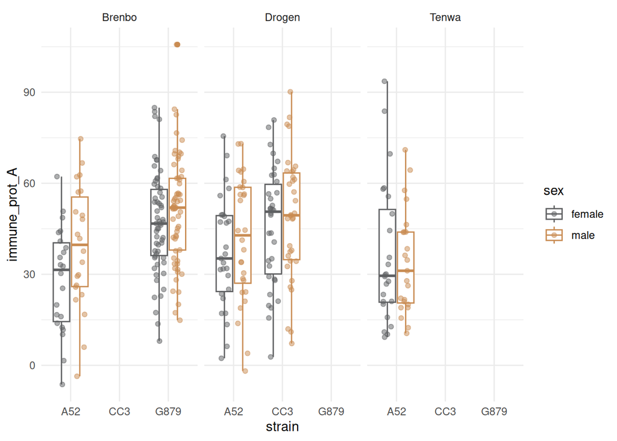

1. List all the variables you see represented in this plot (Tip: there are 4).

**Expand to see the answer**

- strain
- town
- sex
- immune_prot_A

If you thought “Brenbo”, “Drogen” and “Tenwa” were variables, look at the data table again. They are not variables, but *observations* inside the `town` variable. The same is true for “A52”, “CC3” and “G879”. They are observations in the `strain` variable.

2. Which colour represents the female participants?

**Expand to see the answer**

grey

3. True or false: Immune protein A was slightly higher in females with strain A52, who lived in Drogen.

**Expand to see the answer**

False. You can find the answer in the middle panel, by looking at the two boxplots aligned with strain A52.

4. True or false: There were no participants from Brenbo who were ill with the CC3 strain.

**Expand to see the answer**

True. In the left panel, there is no plot for CC3, because the dataset contained no data for participants from Brenbo with that strain.

Data are information we capture about individuals, events or phenomena. We usually make it useful by putting it into a format that organises it, like a table, so that pieces of information that belong together, are together. When data are in a tidy table, we can usually call the rows *observations* and the columns *variables*.

Data *are* may sound strange to you, but the word data is actually the plural of the word *datum*, which is one data point. See https://www.collinsdictionary.com/dictionary/english/datum.

The variables can have different types, according to what they represent, as listed in the table below.

| Data type | Data subtype | Definition |
| --- | --- | --- |
| categorical | nominal | Variables with categories (rather than numbers). Nominal is when the categories have no natural order. |
|  | ordinal | Variable with categories of things (rather than numbers). Ordinal is when the categories have a natural order, like 'high' and 'low'. |
| numeric | discrete | Variables with numbers only. Discrete is when the numbers are whole numbers (no decimal possible), like apples or children. |
|  | continuous | Variables with numbers only. Continuous is when the numbers can have decimals, which can stretch to infinity. |